# Analysing RSS data with tidyRSS

Robert Myles McDonnell

2019-05-22

[figure not shown]

## Introduction

tidyRSS is a package for extracting data from [RSS feeds](https://en.wikipedia.org/wiki/RSS). It has one function, `tidyfeed()`, which takes one argument, the url of the feed. Included in the package is a simple dataset, a list of feed urls, which you can use to experiment with (they were taken from [here](https://raw.githubusercontent.com/DataWookie/feedeR/master/tests/testthat/test-feeds.txt)). This vignette is designed to give you an idea of what tidyRSS can be used for.

## Installation

tidyRSS can be installed from GitHub, using the devtools package, or from CRAN directly.

```r
devtools::install_github("robertmyles/tidyrss")


install.packages("tidyRSS")
```

## Usage

As tidyRSS is based on the idea of tidy data, it forms part of the [tidyverse](http://tidyverse.org/), which means that it plays nice with any tidy-style package. Visualizations, summaries, further manipulation is all easy thanks to this underlying common structure. For example, we can take a look at how statistician and political scientist [Andrew Gelman](http://andrewgelman.com/) has been feeling, at least from the (very!) superficial means of judging his blog post titles.

```r
library(tidyRSS)

rss <- tidyfeed("http://andrewgelman.com/feed/")
```

Since the data are already in a tidy format, it’s straightforward to use it with other tidyverse packages such as tidytext.

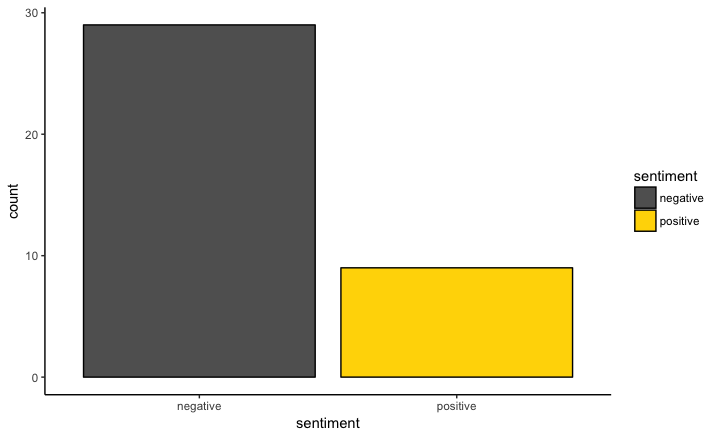

```r
library(tidytext)
library(dplyr)
library(ggplot2)

data("stop_words")

rss_t <- rss %>%
  unnest_tokens(word, item_title) %>%
  anti_join(stop_words) %>%
  inner_join(get_sentiments("bing"), by = "word") %>%
  mutate(week = week(item_date))

ggplot(rss_t, aes(x = sentiment)) +
  geom_bar(aes(fill = sentiment), colour = "black") +
  theme_classic() +
  scale_fill_manual(values = c("#616161", "#FFD700"))
```